# Lab Four: Evaluation and Multi-Layer Perceptron

### By Xiangying Chang, Fang Qi, Rui Lin, Shimeng Yuan

# 1.Preparation

## 1.1 Business Understanding

This dataset has over 370,000 instances of used cars and 20 features, including both categorical and numerical features. It matches the Lab requirement and is free to download at kaggle.com.

Driving is a common way to go out in the United States. US vehicle registration data shows that about 276.1 million vehicles were registered in 2018. The United States is one of the largest automobile markets around the world. In the overall US automotive market, the used car market is an important component. According to the statistics from statista.com released in March 2018, sales of new car dropped to 17.1 million vehicles while sales of used car climbed to an all-time high of 42.7 million vehicles in 2017. In the used car market, price is always a significant issue for both sellers and buyers because sellers want to sell a car at the highest price while buyers want to buy an ideal used car at the lowest price.

So we decided to use 8 different kinds of price range to help us to explore the features relationship.  
(0: price < $2000; 1: $2000 < price < $5000; 2: $5000 < price < $10000; 3: $10000 < price < $15000; 4: $15000 < price < $20000; 5: $20000 < price < $25000; 6: $25000 < price < $30000; 7: $30000 < price. )

Through visualizing the features, exploring the features relationship, and other methods, we are able to help sellers and buyers to understand the most significant issues leading to the price range of used car. From the analyzing, the sellers could have an idea what kind of price range they can sell at to maximize their benefits, and the buyers could have an idea what kind of the best used car they can buy under their budgets. The end goal of analyzing a dataset like this would be to help sellers and buyers to predict the price range of car based on the different features of car they have.

We are trying to used the past data to analysis what features will affect the price range most, or which decided the car's price range. And we split our data to test whether the factors we found are really affect a used car's price range when we do prediction. If the algorithm is learning properly, we expect the difference between the actual price and the predicted price range as small as possible. This may help some websites which are helping value the used cars' price range, like Kelly Blue Book, to predict the cars' value range more accuray. That's what we are trying to achieve in this Lab.

Dataset Source: https://www.kaggle.com/orgesleka/used-cars-database

References:

https://www.kbb.com/  
https://hedgescompany.com/automotive-market-research-statistics/auto-mailing-lists-and-marketing/ https://www.statista.com/statistics/183713/value-of-us-passenger-cas-sales-and-leases-since-1990/

## 1.2 Data Understanding

### 1.2.1 Preparing the data (Get clean data can be used to predict)

```python
import pandas as pd
import numpy as np
import seaborn as sns
import matplotlib as mpl
import matplotlib.pyplot as plt
import missingno as mn
import warnings
warnings.filterwarnings("ignore")
%matplotlib inline

df = pd.read_csv('autos.csv',encoding='latin_1')

df.head() # Show the name of each column
```

|  | dateCrawled | name | seller | offerType | price | abtest | vehicleType | yearOfRegistration | gearbox | powerPS | model | kilometer | monthOfRegistration | fuelType | brand | notRepairedDamage | dateCreated | nrOfPictures | postalCode | lastSeen |
| --- | --- | --- | --- | --- | --- | --- | --- | --- | --- | --- | --- | --- | --- | --- | --- | --- | --- | --- | --- | --- |
| 0 | 2016-03-24 11:52:17 | Golf_3_1.6 | privat | Angebot | 480 | test | NaN | 1993 | manuell | 0 | golf | 150000 | 0 | benzin | volkswagen | NaN | 2016-03-24 00:00:00 | 0 | 70435 | 2016-04-07 03:16:57 |
| 1 | 2016-03-24 10:58:45 | A5_Sportback_2.7_Tdi | privat | Angebot | 18300 | test | coupe | 2011 | manuell | 190 | NaN | 125000 | 5 | diesel | audi | ja | 2016-03-24 00:00:00 | 0 | 66954 | 2016-04-07 01:46:50 |
| 2 | 2016-03-14 12:52:21 | Jeep_Grand_Cherokee_"Overland" | privat | Angebot | 9800 | test | suv | 2004 | automatik | 163 | grand | 125000 | 8 | diesel | jeep | NaN | 2016-03-14 00:00:00 | 0 | 90480 | 2016-04-05 12:47:46 |
| 3 | 2016-03-17 16:54:04 | GOLF_4_1_4__3TÜRER | privat | Angebot | 1500 | test | kleinwagen | 2001 | manuell | 75 | golf | 150000 | 6 | benzin | volkswagen | nein | 2016-03-17 00:00:00 | 0 | 91074 | 2016-03-17 17:40:17 |
| 4 | 2016-03-31 17:25:20 | Skoda_Fabia_1.4_TDI_PD_Classic | privat | Angebot | 3600 | test | kleinwagen | 2008 | manuell | 69 | fabia | 90000 | 7 | diesel | skoda | nein | 2016-03-31 00:00:00 | 0 | 60437 | 2016-04-06 10:17:21 |

```python
df.info() # Based information about each column type
```

```
<class 'pandas.core.frame.DataFrame'>
RangeIndex: 371528 entries, 0 to 371527
Data columns (total 20 columns):
dateCrawled            371528 non-null object
name                   371528 non-null object
seller                 371528 non-null object
offerType              371528 non-null object
price                  371528 non-null int64
abtest                 371528 non-null object
vehicleType            333659 non-null object
yearOfRegistration     371528 non-null int64
gearbox                351319 non-null object
powerPS                371528 non-null int64
model                  351044 non-null object
kilometer              371528 non-null int64
monthOfRegistration    371528 non-null int64
fuelType               338142 non-null object
brand                  371528 non-null object
notRepairedDamage      299468 non-null object
dateCreated            371528 non-null object
nrOfPictures           371528 non-null int64
postalCode             371528 non-null int64
lastSeen               371528 non-null object
dtypes: int64(7), object(13)
memory usage: 56.7+ MB
```

```python
df.describe()
```

|  | price | yearOfRegistration | powerPS | kilometer | monthOfRegistration | nrOfPictures | postalCode |
| --- | --- | --- | --- | --- | --- | --- | --- |
| count | 3.715280e+05 | 371528.000000 | 371528.000000 | 371528.000000 | 371528.000000 | 371528.0 | 371528.00000 |
| mean | 1.729514e+04 | 2004.577997 | 115.549477 | 125618.688228 | 5.734445 | 0.0 | 50820.66764 |
| std | 3.587954e+06 | 92.866598 | 192.139578 | 40112.337051 | 3.712412 | 0.0 | 25799.08247 |
| min | 0.000000e+00 | 1000.000000 | 0.000000 | 5000.000000 | 0.000000 | 0.0 | 1067.00000 |
| 25% | 1.150000e+03 | 1999.000000 | 70.000000 | 125000.000000 | 3.000000 | 0.0 | 30459.00000 |
| 50% | 2.950000e+03 | 2003.000000 | 105.000000 | 150000.000000 | 6.000000 | 0.0 | 49610.00000 |
| 75% | 7.200000e+03 | 2008.000000 | 150.000000 | 150000.000000 | 9.000000 | 0.0 | 71546.00000 |
| max | 2.147484e+09 | 9999.000000 | 20000.000000 | 150000.000000 | 12.000000 | 0.0 | 99998.00000 |

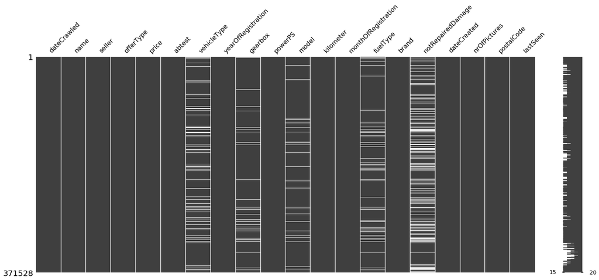

```python
mn.matrix(df.sort_values(by=["name",]))
```

In order to complete the cleaning process, we need to sum up the number of thr missing value under each column

```python
print(df.isnull().sum())
```

```
dateCrawled                0
name                       0
seller                     0
offerType                  0
price                      0
abtest                     0
vehicleType            37869
yearOfRegistration         0
gearbox                20209
powerPS                    0
model                  20484
kilometer                  0
monthOfRegistration        0
fuelType               33386
brand                      0
notRepairedDamage      72060
dateCreated                0
nrOfPictures               0
postalCode                 0
lastSeen                   0
dtype: int64
```

According to the results, we get some missing numbers for 'vehicleType', 'gearbox', 'model', 'fuelType', 'notRepairedDamage'. Then we need to cleaning these missing values for these features. What we need is to predict the price range of used cars, we think 'vehicleType', 'gearbox', 'model', 'fuelType' are the most associated with 'price', and those missing data for our view, we think they are most likely to be the loss of information, not mistakes, so we decide to drop these null values.

```python
df_notnull = df[(df['vehicleType'].notnull()) & (df['gearbox'].notnull()) & (df['model'].notnull())
                     & (df['fuelType'].notnull())]
df_notnull.info()
```

```
<class 'pandas.core.frame.DataFrame'>
Int64Index: 299864 entries, 2 to 371527
Data columns (total 20 columns):
dateCrawled            299864 non-null object
name                   299864 non-null object
seller                 299864 non-null object
offerType              299864 non-null object
price                  299864 non-null int64
abtest                 299864 non-null object
vehicleType            299864 non-null object
yearOfRegistration     299864 non-null int64
gearbox                299864 non-null object
powerPS                299864 non-null int64
model                  299864 non-null object
kilometer              299864 non-null int64
monthOfRegistration    299864 non-null int64
fuelType               299864 non-null object
brand                  299864 non-null object
notRepairedDamage      260956 non-null object
dateCreated            299864 non-null object
nrOfPictures           299864 non-null int64
postalCode             299864 non-null int64
lastSeen               299864 non-null object
dtypes: int64(7), object(13)
memory usage: 48.0+ MB
```

Now, besides feature:'notRepairedDamage', there is not any other missing data for other features. Set the null field in notRepairedDamage to "not declare"

```python
df_notnull['notRepairedDamage'].fillna(value='not declare', inplace=True)
df_notnull.info()
```

```
<class 'pandas.core.frame.DataFrame'>
Int64Index: 299864 entries, 2 to 371527
Data columns (total 20 columns):
dateCrawled            299864 non-null object
name                   299864 non-null object
seller                 299864 non-null object
offerType              299864 non-null object
price                  299864 non-null int64
abtest                 299864 non-null object
vehicleType            299864 non-null object
yearOfRegistration     299864 non-null int64
gearbox                299864 non-null object
powerPS                299864 non-null int64
model                  299864 non-null object
kilometer              299864 non-null int64
monthOfRegistration    299864 non-null int64
fuelType               299864 non-null object
brand                  299864 non-null object
notRepairedDamage      299864 non-null object
dateCreated            299864 non-null object
nrOfPictures           299864 non-null int64
postalCode             299864 non-null int64
lastSeen               299864 non-null object
dtypes: int64(7), object(13)
memory usage: 48.0+ MB
```

```python
df_dropduplicates = df_notnull.drop_duplicates(['dateCrawled',])
df_dropduplicates.info()
```

```
<class 'pandas.core.frame.DataFrame'>
Int64Index: 239081 entries, 2 to 371527
Data columns (total 20 columns):
dateCrawled            239081 non-null object
name                   239081 non-null object
seller                 239081 non-null object
offerType              239081 non-null object
price                  239081 non-null int64
abtest                 239081 non-null object
vehicleType            239081 non-null object
yearOfRegistration     239081 non-null int64
gearbox                239081 non-null object
powerPS                239081 non-null int64
model                  239081 non-null object
kilometer              239081 non-null int64
monthOfRegistration    239081 non-null int64
fuelType               239081 non-null object
brand                  239081 non-null object
notRepairedDamage      239081 non-null object
dateCreated            239081 non-null object
nrOfPictures           239081 non-null int64
postalCode             239081 non-null int64
lastSeen               239081 non-null object
dtypes: int64(7), object(13)
memory usage: 38.3+ MB
```

No matter the null values or the duplicate data, we think these quality issues exist are because of the manual input error, so we optimized the data through methods showed above.

###### #

After drop duplicate data, we find some features are not very associated with price, so we decide to delete some features.There are few strange features and values, in order to cleaning the data, we are going to inspect several features to show why we remove them, and the other undesired columns are removed for same purpose

```python
print(df_dropduplicates['nrOfPictures'].sum()) # From this we need to delete nrOfPictures
print('=======================================')
print(df_dropduplicates.groupby('seller').size()) # From this we need to delete seller
print('=======================================')
print(df_dropduplicates.groupby('offerType').size())
print('=======================================')
print(df_dropduplicates.groupby('abtest').size())
print('=======================================')


# drop these features showed above and few others which I don't need under same purpose
df_new = df_dropduplicates.drop(['dateCrawled', 'monthOfRegistration', 'dateCreated', 'lastSeen','seller','offerType','abtest','nrOfPictures'], 1)
df_new.info()
```

```
0
=======================================
seller
gewerblich         3
privat        239078
dtype: int64
=======================================
offerType
Angebot    239079
Gesuch          2
dtype: int64
=======================================
abtest
control    114740
test       124341
dtype: int64
=======================================
<class 'pandas.core.frame.DataFrame'>
Int64Index: 239081 entries, 2 to 371527
Data columns (total 12 columns):
name                  239081 non-null object
price                 239081 non-null int64
vehicleType           239081 non-null object
yearOfRegistration    239081 non-null int64
gearbox               239081 non-null object
powerPS               239081 non-null int64
model                 239081 non-null object
kilometer             239081 non-null int64
fuelType              239081 non-null object
brand                 239081 non-null object
notRepairedDamage     239081 non-null object
postalCode            239081 non-null int64
dtypes: int64(5), object(7)
memory usage: 23.7+ MB
```

## clean useless data

Since if the car is too old or too new, too cheap or too expensive, runed too few miles or too many miles,too few PS or too many PS has less comparison values, so we are going to remove these cars too. So we are going to analyze the cars registerd between 1980 and 2017, running kilometers between 5000kms and 200000kms, PowerPs between 50 and 500, and price between 500 - 150000

```python
print("Too new: %d" % df_new.loc[df_dropduplicates.yearOfRegistration > 2017].count()['name'])
print("Too old: %d" % df_new.loc[df_dropduplicates.yearOfRegistration < 1980].count()['name'])
print("Too cheap: %d" % df_new.loc[df_dropduplicates.price < 500].count()['name'])
print("Too expensive: " , df_new.loc[df_dropduplicates.price > 150000].count()['name'])
print("Too few km: " , df_new.loc[df_dropduplicates.kilometer < 5000].count()['name'])
print("Too many km: " , df_new.loc[df_dropduplicates.kilometer > 200000].count()['name'])
print("Too few PS: " , df_new.loc[df_dropduplicates.powerPS < 50].count()['name'])
print("Too many PS: " , df_new.loc[df_dropduplicates.powerPS > 500].count()['name'])
```

```
Too new: 2
Too old: 1926
Too cheap: 15598
Too expensive:  91
Too few km:  0
Too many km:  0
Too few PS:  16489
Too many PS:  478
```

Due to the reasons and outputs showed above, we get the final clean data which shows like below, because name is the combine of brand and vechicleType, we already have them in the features, we decide to drop it as well.

```python
df_clean = df_new[(df_new.yearOfRegistration < 2017) & (df_new.yearOfRegistration > 1980)
                             & (df_new.price > 500) & (df_new.price < 150000)
                            & (df_new.kilometer > 5000) & (df_new.kilometer < 200000)
                            & (df_new.powerPS > 50) & (df_new.powerPS < 500)]
df_clean = df_clean.drop(['name'], 1)
df_clean.info()
```

```
<class 'pandas.core.frame.DataFrame'>
Int64Index: 202112 entries, 2 to 371527
Data columns (total 11 columns):
price                 202112 non-null int64
vehicleType           202112 non-null object
yearOfRegistration    202112 non-null int64
gearbox               202112 non-null object
powerPS               202112 non-null int64
model                 202112 non-null object
kilometer             202112 non-null int64
fuelType              202112 non-null object
brand                 202112 non-null object
notRepairedDamage     202112 non-null object
postalCode            202112 non-null int64
dtypes: int64(5), object(6)
memory usage: 18.5+ MB
```